## **Poisson Regression**

##### **Data Background**

Name: A clinical Trial in the Trt. of Carcinoma of the Oropharynx (PHARYNX.DAT) SIZE: 195 observations, 13 variables.

SOURCE: The Statistical Analysis of Failure Time Data, by JD Kalbfleisch & RL Prentice, (1980), Published by John Wiley & Sons http://www.umass.edu/statdata/statdata/data/pharynx.txt

DESCRIPTIVE ABSTRACT:

The .dat file gives the data for a part of a large clinical trial carried out by the Radiation Therapy Oncology Group in the United States. The full study included patients with squamous carcinoma of 15 sites in the mouth and throat, with 16 participating institutions, though only data on three sites in the oropharynx reported by the six largest institutions are considered here. Patients entering the study were randomly assigned to one of two treatment groups, radiation therapy alone or radiation therapy together with a chemotherapeutic agent. One objective of the study was to compare the two treatment policies with respect to patient survival.

VARIABLE DEFINITIONS:

- **CASE**: Case Number
- **INST**: Participating Institution
- **SEX**: 1=male, 2=female
- **TX**: Treatment: 1=standard, 2=test
- **GRADE**: 1=well differentiated, 2=moderately differentiated, 3=poorly differentiated, 9=missing
- **AGE**: In years at time of diagnosis
- **COND**: Condition: 1=no disability, 2=restricted work, 3=requires assistance with self care, 4=bed confined, 9=missing
- **SITE**: 1=faucial arch, 2=tonsillar fossa, 3=posterior pillar, 4=pharyngeal tongue, 5=posterior wall
- **T_STAGE**: 1=primary tumor measuring 2 cm or less in largest diameter, 2=primary tumor measuring 2 cm to 4 cm in largest diameter with minimal infiltration in depth, 3=primary tumor measuring more than 4 cm, 4=massive invasive tumor
- **N_STAGE**: 0=no clinical evidence of node metastases, 1=single positive node 3 cm or less in diameter, not fixed, 2=single positive node more than 3 cm in diameter, not fixed, 3=multiple positive nodes or fixed positive nodes
- **ENTRY_DT**: Date of study entry: Day of year and year, dddyy
- **STATUS**: 0=censored, 1=dead
- **TIME**: Survival time in days from day of diagnosis

```r
options(width = 100)

library(MASS)

dta = read.csv("data/pharynx.csv")

head(dta)
```

```
  CASE INST SEX TX GRADE AGE COND SITE T_STAGE N_STAGE ENTRY_DT STATUS TIME
1    1    2   2  1     1  51    1    2       3       1     2468      1  631
2    2    2   1  2     1  65    1    4       2       3     2968      1  270
3    3    2   1  1     2  64    2    1       3       3     3368      1  327
4    4    2   1  1     1  73    1    1       4       0     5768      1  243
5    5    5   1  2     2  64    1    1       4       3     9568      1  916
6    6    4   1  2     1  61    1    2       3       0    10668      0 1823
```

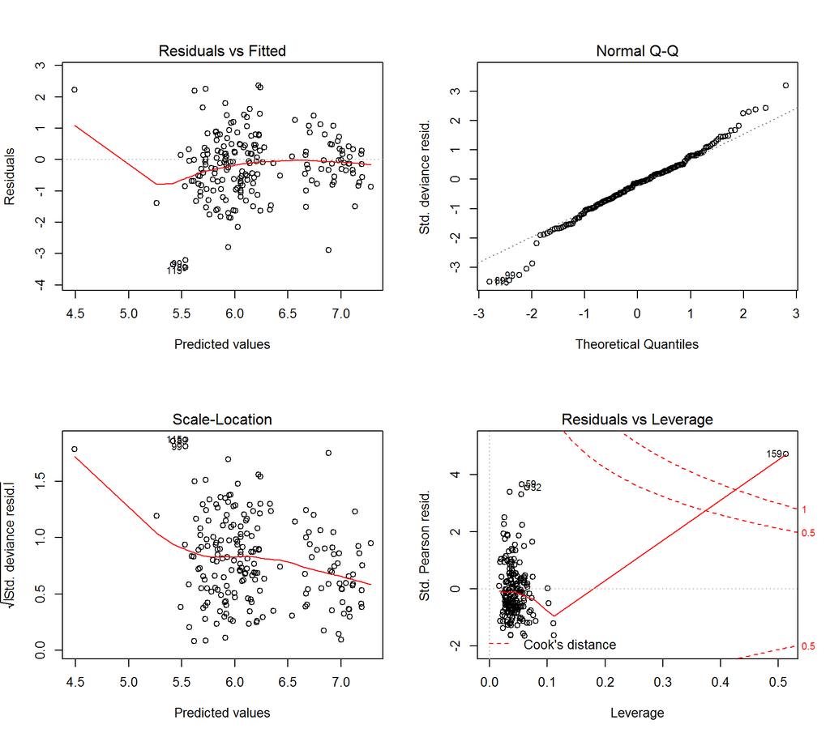

```r
## Poisson Regression Model for Survival Time
mdl = glm(TIME ~ SEX + TX + AGE + COND + SITE + T_STAGE + N_STAGE + STATUS,
          family = poisson(), data = dta)

## Negative Binomial Model for Survival Time
mdl2 = glm.nb(TIME ~ SEX + TX + AGE + COND + SITE + T_STAGE + N_STAGE + STATUS,
              maxit = 100, data = dta)

## Dispersion paramater > 0 so poisson is not appropriate, negative binomial is a better model
par(mfrow = c(2,2))
plot(mdl2)
```

```r
## Remove the outlier observation and retrain
dta = dta[-159, ]

mdl.nb = glm.nb(TIME ~ SEX + TX + AGE + COND + SITE + T_STAGE + N_STAGE + STATUS,
              maxit = 100, data = dta)

summary(mdl.nb)
```

```
Call:
glm.nb(formula = TIME ~ SEX + TX + AGE + COND + SITE + T_STAGE +
    N_STAGE + STATUS, data = dta, maxit = 100, init.theta = 3.121080189,
    link = log)

Deviance Residuals:
    Min       1Q   Median       3Q      Max
-3.3855  -0.8138  -0.2142   0.4034   2.2540

Coefficients:
             Estimate Std. Error z value Pr(>|z|)
(Intercept)  7.646448   0.369792  20.678   <2e-16 ***
SEX          0.142239   0.098324   1.447   0.1480
TX          -0.140805   0.082706  -1.702   0.0887 .
AGE          0.006148   0.003802   1.617   0.1059
COND        -0.510610   0.076821  -6.647    3e-11 ***
SITE        -0.006501   0.034988  -0.186   0.8526
T_STAGE     -0.119522   0.053337  -2.241   0.0250 *
N_STAGE     -0.058860   0.036701  -1.604   0.1088
STATUS      -0.886395   0.094450  -9.385   <2e-16 ***
---
Signif. codes:  0 '***' 0.001 '**' 0.01 '*' 0.05 '.' 0.1 ' ' 1

(Dispersion parameter for Negative Binomial(3.1211) family taken to be 1)

    Null deviance: 385.38  on 193  degrees of freedom
Residual deviance: 205.16  on 185  degrees of freedom
AIC: 2704.2

Number of Fisher Scoring iterations: 1

              Theta:  3.121
          Std. Err.:  0.306

 2 x log-likelihood:  -2684.213
```

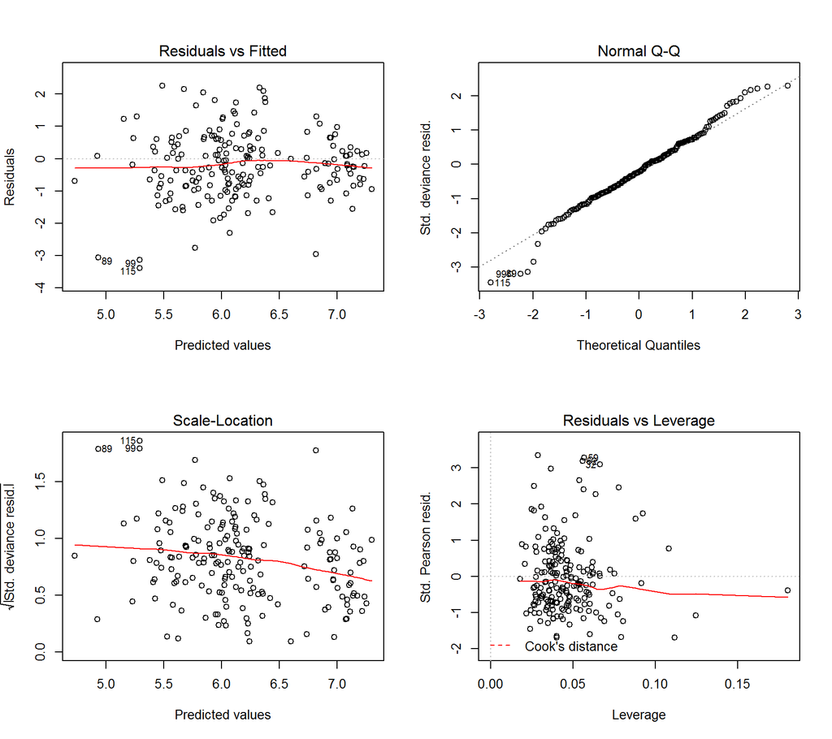

```r
plot(mdl.nb)
```